# 04_cluster_analysis

Maryam Shojaei Shahrokhabadi

2026-01-07

```r
knitr::opts_chunk$set(echo = FALSE)
```

## 1. Introduction

The previous analyses used the known leukemia type of each patient to find genes and build classifiers. This analysis asks a different question: if the labels were unknown, would the gene expression data on their own reveal natural groups of patients, and would those groups correspond to the two leukemia types?

The data consist of 7,128 genes measured in 72 patients, 47 with acute lymphoblastic leukemia (ALL) and 25 with acute myeloid leukemia (AML). The labels are used only at the end, to evaluate the clusters, and never to form them.

## 2. Methods

### 2.1 Gene Filtering

Most genes show little variation between patients and mainly add noise to the clustering analysis. To focus on genes that carry information about differences between patients, the 100 genes with the highest variance across all patients were retained. This filtering does not use the leukemia labels, so the analysis remains fully unsupervised.

### 2.2 Choosing the Number of Clusters

Clustering methods do not determine the number of groups automatically. The gap statistic compares the compactness of the clusters in the observed data with the compactness expected under reference datasets with no underlying cluster structure. Following Tibshirani et al. (2001), the selected number of clusters is the smallest $k$ satisfying

$$\text{Gap}(k) \geq \text{Gap}(k+1) - s_{k+1},$$

where $s_{k+1}$ is the standard error of $\text{Gap}(k+1)$. In other words, a larger number of clusters is selected only when the improvement in the gap statistic is sufficiently large relative to its uncertainty. The gap statistic was calculated using 500 reference datasets.

### 2.3 Clustering Methods

Two methods were applied to the 100 selected genes:

- **Hierarchical clustering** (agglomerative, Euclidean distance, average linkage) builds a tree in which the most similar patients are joined first. Cutting the tree at a given height produces clusters, and the tree itself shows the structure at all levels.
- **K-means clustering** divides patients into $k$ groups so that each patient is as close as possible to the mean of its group. Because the result depends on the random starting points, the algorithm was run from 25 different starts and the best solution was kept.

### 2.4 Evaluation

The clusters were compared with the true leukemia types using contingency tables and the agreement rate, the proportion of patients whose cluster corresponds to their true type.

## 3. Results

### 3.1 Data Exploration

Figure 1 shows the patients projected onto the first two principal components, coloured by their true leukemia type, using all genes and only the 100 most variable genes. With all genes, the two types overlap considerably. After filtering, the separation between ALL and AML becomes much clearer, mostly along the first principal component. This suggests that the filtered data contain a strong group structure that clustering methods should be able to detect.

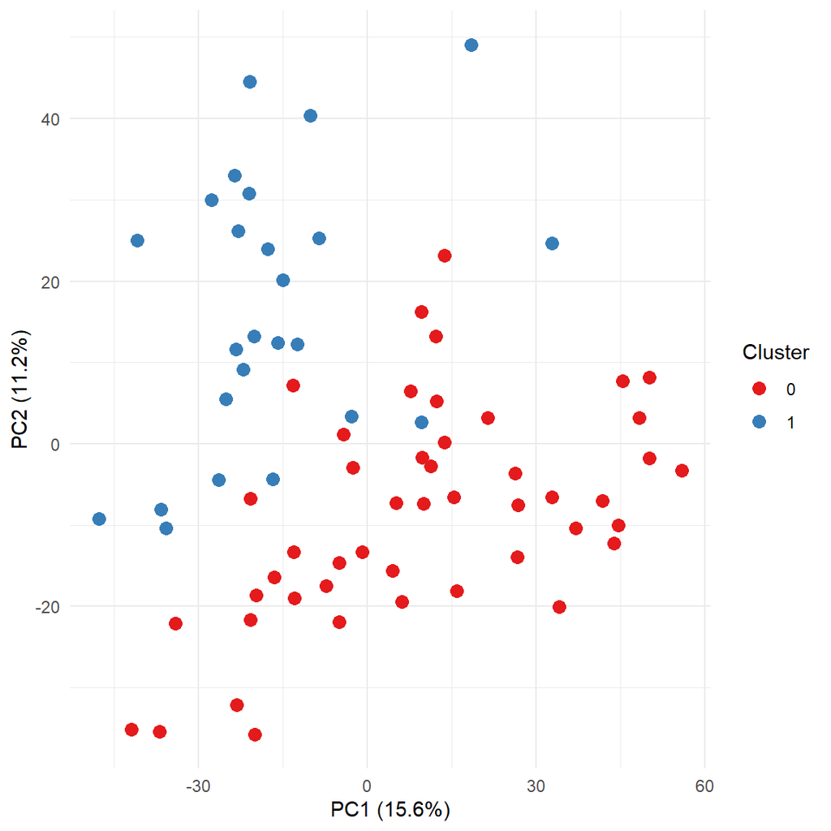

**(a): All 7,128 genes.**

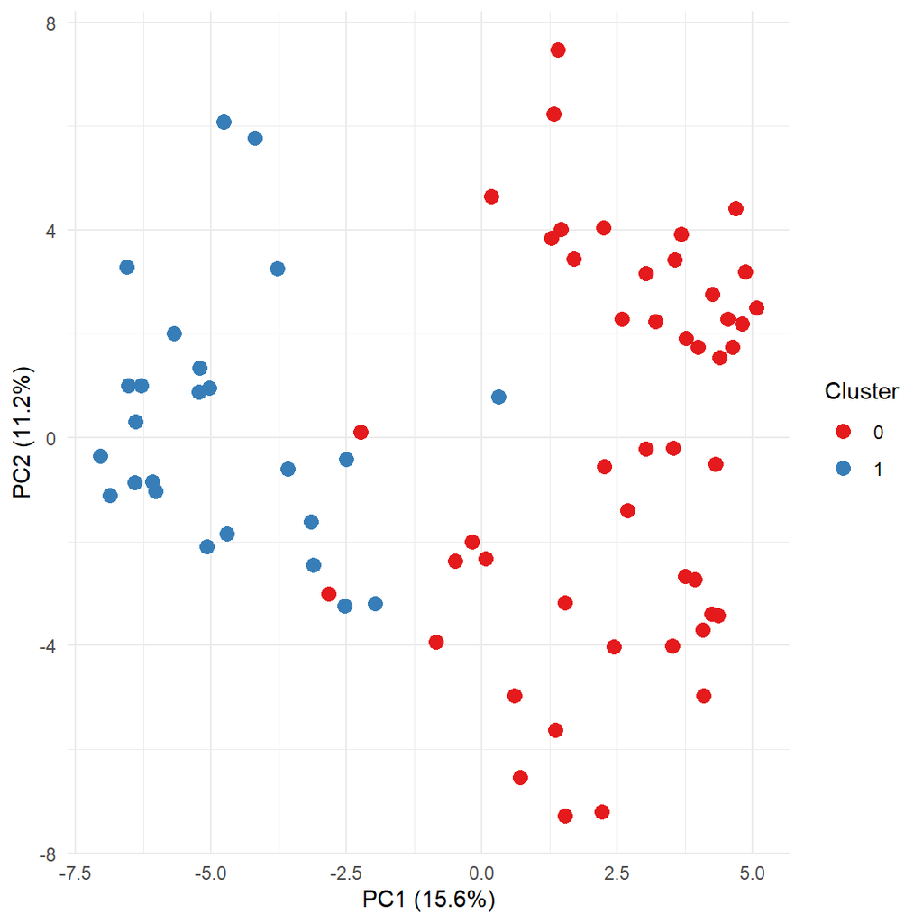

**(b): 100 most variable genes.**

**Figure 1. First two principal components, coloured by true leukemia type, using (a): all genes and (b) the 100 most variable genes.**

### 3.2 Number of Clusters

Figure 2 shows the gap statistic for 1 to 15 clusters. The left panel shows the difference between the gap statistic for $k$ clusters and the gap statistic for $k+1$ clusters, adjusted for the standard error. According to the one-standard-error criterion, the smallest $k$ satisfying the selection rule is $k=2$. The improvement from one to two clusters is substantial, whereas adding a third cluster does not provide a sufficiently large improvement relative to its uncertainty. Therefore, the gap statistic selects **$k=2$** clusters. Although the gap statistic itself continues to increase up to around six clusters, these increases are relatively small compared with their associated standard errors and do not justify selecting a larger number of clusters.

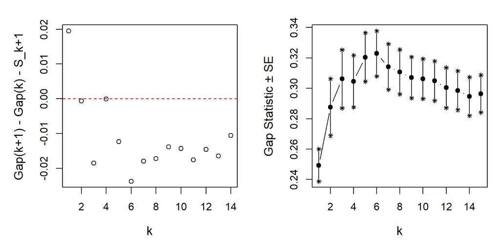

**Figure 2. Left: gap criterion for each number of clusters; the chosen k is the first value at or below the dashed line. Right: gap statistic with standard errors.**

## Hierarchical clustering

Figure 3 shows the dendrogram from hierarchical clustering. The tree splits into two main branches, of 20 and 52 patients. The smaller branch consists of AML patients, while the larger branch contains the ALL patients together with a few AML patients, so the tree recovers the main division between the two types but places some AML patients with the ALL group.

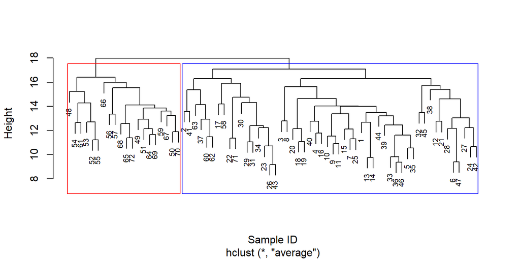

**Figure 3. Dendrogram from hierarchical clustering (Euclidean distance, average linkage), cut into two clusters.**

## K-means clustering

K-means with $k = 2$ produced clusters of 26 and 46 patients, very close to the true group sizes of 25 AML and 47 ALL. Figure 4 compares the k-means clusters with the true leukemia types in the space of the first two principal components. The two plots are almost identical: k-means separates the patients mainly along the first principal component, which is the same direction that separates ALL from AML.

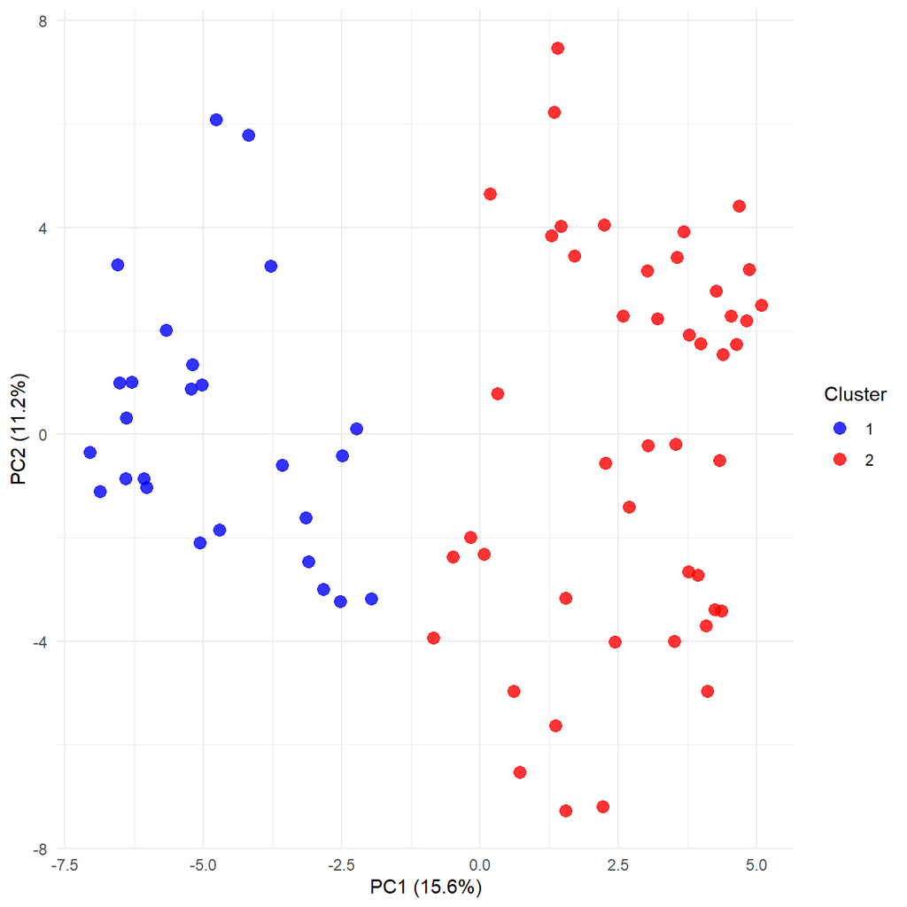

**(a): K-means clusters.**

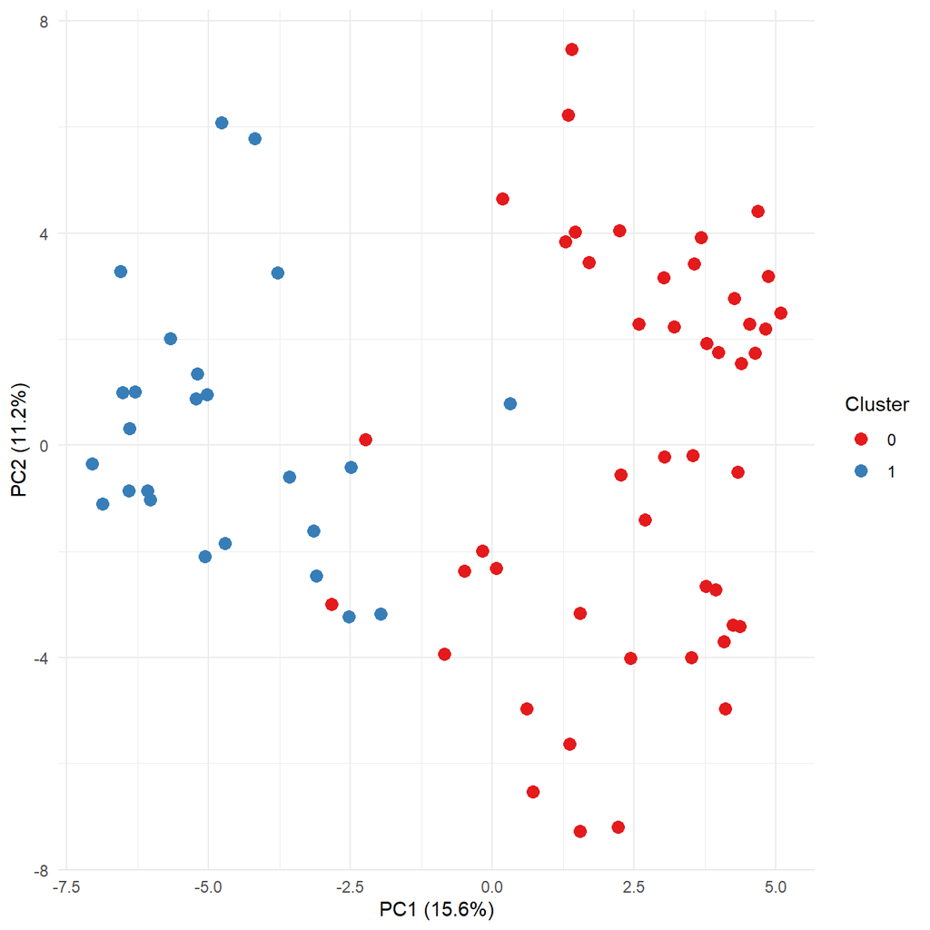

**(b): True leukemia type.**

**Figure 4. Patients on the first two principal components of the 100 most variable genes, coloured by (a): k-means cluster and (b):true leukemia typ.**

### 3.5 Comparison with the True Leukemia Types

The comparison with the known leukemia labels shows that both clustering methods separate the ALL and AML patients very well. K-means produces two clusters that are almost perfectly aligned with the leukemia types: Cluster 1 contains 24 AML and only 2 ALL patients, while Cluster 2 contains 45 ALL and only 1 AML patient. Thus, the two clusters correspond very closely to AML and ALL, respectively.

Hierarchical clustering also shows a strong separation. One cluster contains all 47 ALL patients and 5 AML patients, while the other contains the remaining 20 AML patients and no ALL patients. Therefore, both methods recover a clear structure that closely corresponds to the known leukemia types, with K-means showing slightly better agreement with the true labels.

| Method | Cluster | ALL | AML |
| --- | --- | --- | --- |
| K-means | Cluster 1 | 2 | 24 |
|  | Cluster 2 | 45 | 1 |
| Hierarchical | Cluster 1 | 47 | 5 |
|  | Cluster 2 | 0 | 20 |

## 4. Conclusion

Without using the leukemia labels, both clustering methods identified two groups of patients that correspond closely to ALL and AML. The gap statistic supported two clusters, matching the true number of leukemia types. K-means reproduced the true groups most closely, while hierarchical clustering with average linkage placed several AML patients with the ALL group. Filtering to the 100 most variable genes was important: with all genes, the two types overlapped considerably, while after filtering the separation was clear.

These results show that leukemia type is the dominant source of variation in the expression data. This is consistent with the earlier analyses, in which a small number of genes was enough to classify patients with high accuracy.